## Part 3 : Analysis

### Replace the NAs by the mean of the closest observations

Before starting with the analysis we know that some of the models we use do not work with NAs. To deal with them, we decided to replace the 2 NAs we have by the mean of their closest observations.

### Splitting the data into Traning set and Test set

The next step is to split our data set into a training set (**Mountain_data.tr_notsubs**) and a test set (**Mountain_data.te**). The training set has 75% of the observations and the test set has the 25% remainder.

### Balancing the Training set

As discussed in the EDA part, we should balance our data because we do not have the same amount of information on each mountains. We have more observations on **Sierra de Guadarrama** and half less on **Central Andes**.

We balanced the data on the training set **Mountain_data.tr_notsubs**.

```
##
##        Central Andes     Central Pyrenees Sierra de Guadarrama
##                   79                   79                   79
```

Now we see that all three mountains has the same amount of observations. We decided to sub-samples the observations because we think that duplicating them will create more biases as we do not have that many observations.

Our new training set is **Mountain_data.tr**.

### Neural Network Model

We start by fitting a Neural Network model on our balanced training set (**Mountain_data.tr**). In order to choose the parameters of this neural network, we applied a simple hyperparameter tuning.

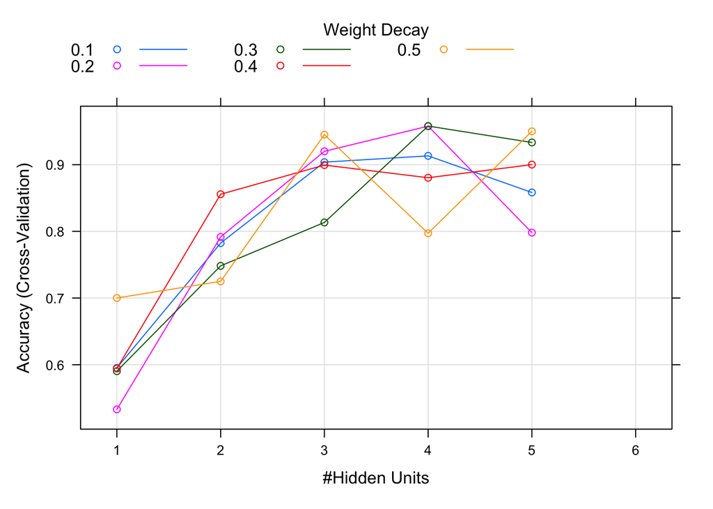

The manually written Neural Network model

### Accuracy of Neural Network

```
## Confusion Matrix and Statistics
##
##                       Reference
## Prediction             Central Andes Central Pyrenees Sierra de Guadarrama
##   Central Andes                   21                0                    0
##   Central Pyrenees                 0               29                    0
##   Sierra de Guadarrama             0                0                   58
##
## Overall Statistics
##
##                Accuracy : 1
##                  95% CI : (0.9664, 1)
##     No Information Rate : 0.537
##     P-Value [Acc > NIR] : < 2.2e-16
##
##                   Kappa : 1
##
##  Mcnemar's Test P-Value : NA
##
## Statistics by Class:
##
##                      Class: Central Andes Class: Central Pyrenees
## Sensitivity                        1.0000                  1.0000
## Specificity                        1.0000                  1.0000
## Pos Pred Value                     1.0000                  1.0000
## Neg Pred Value                     1.0000                  1.0000
## Prevalence                         0.1944                  0.2685
## Detection Rate                     0.1944                  0.2685
## Detection Prevalence               0.1944                  0.2685
## Balanced Accuracy                  1.0000                  1.0000
##                      Class: Sierra de Guadarrama
## Sensitivity                                1.000
## Specificity                                1.000
## Pos Pred Value                             1.000
## Neg Pred Value                             1.000
## Prevalence                                 0.537
## Detection Rate                             0.537
## Detection Prevalence                       0.537
## Balanced Accuracy                          1.000
```

### Naive Bayes

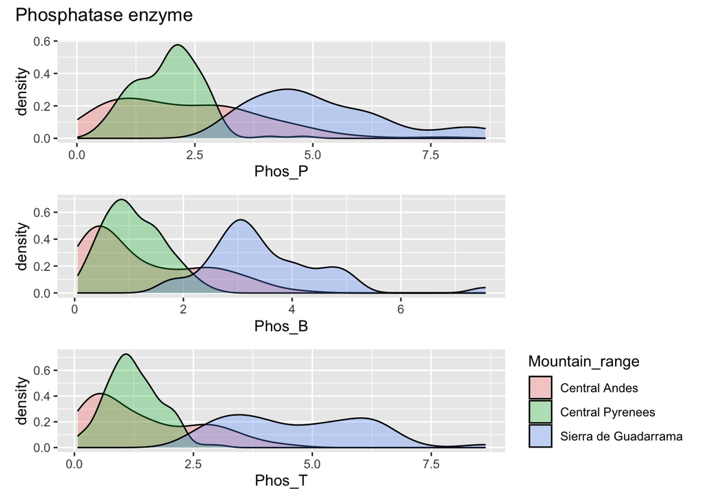

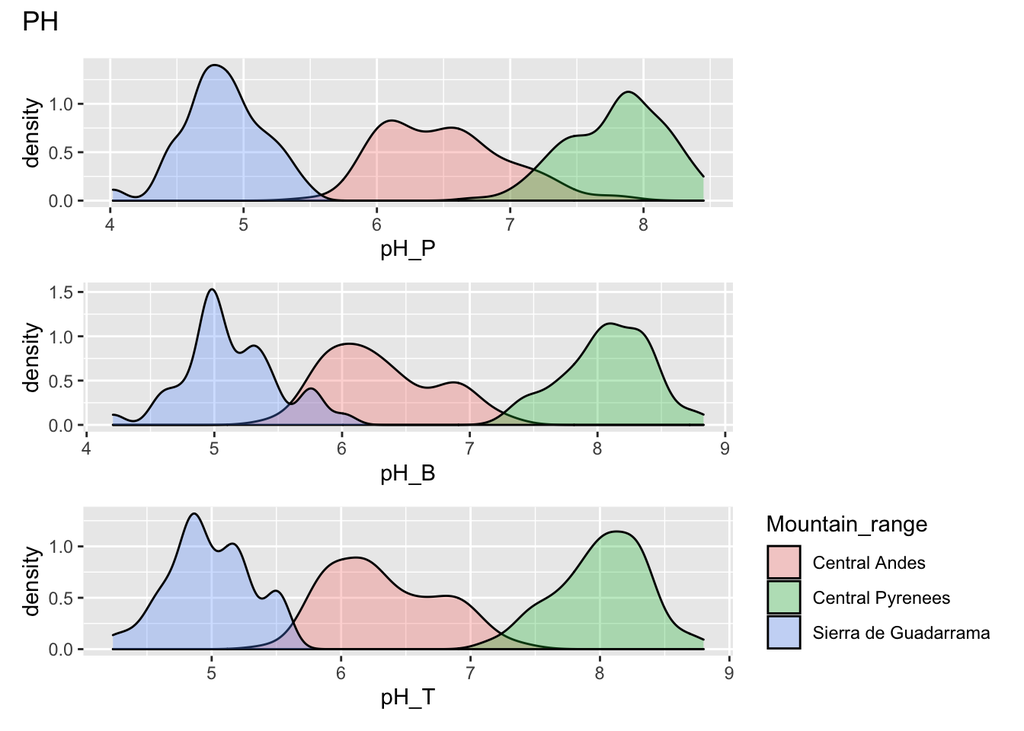

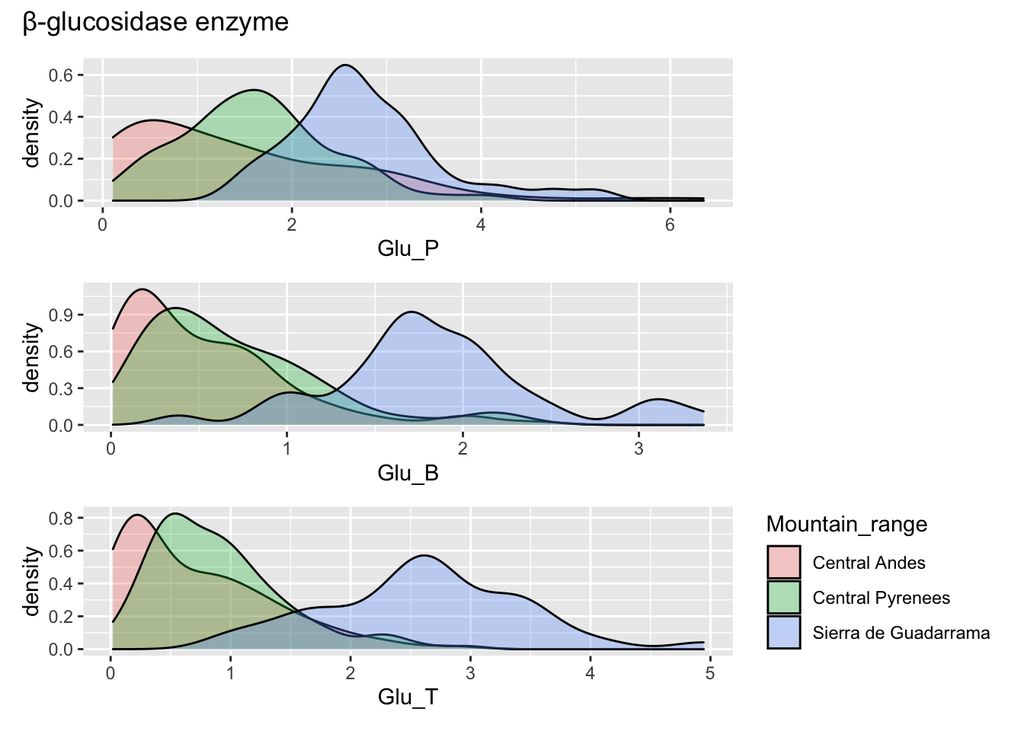

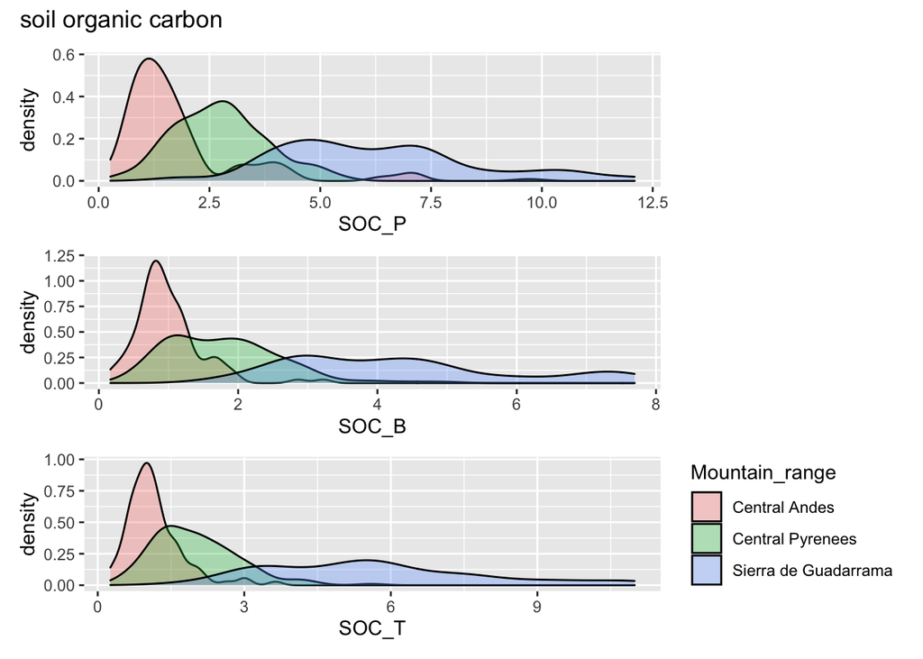

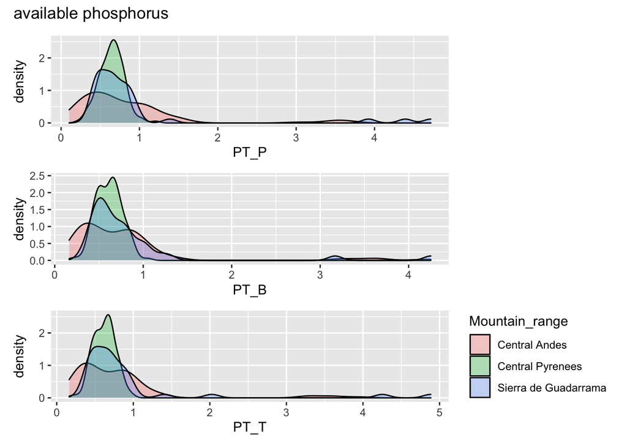

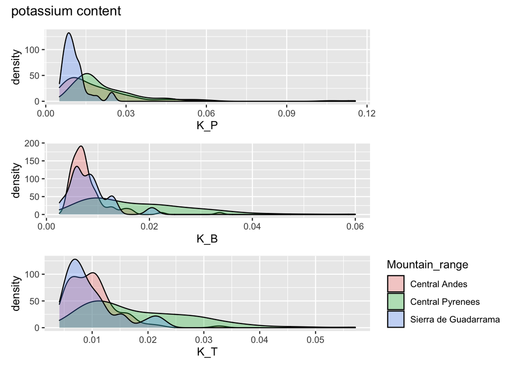

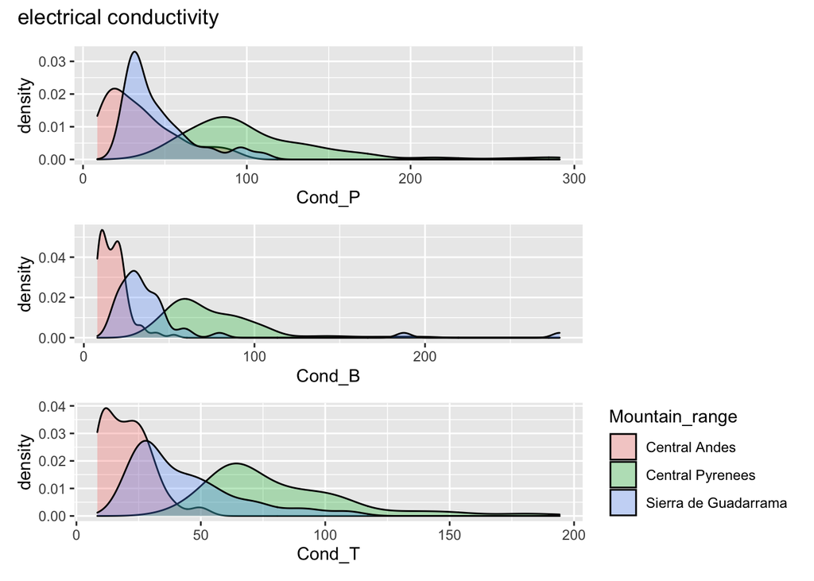

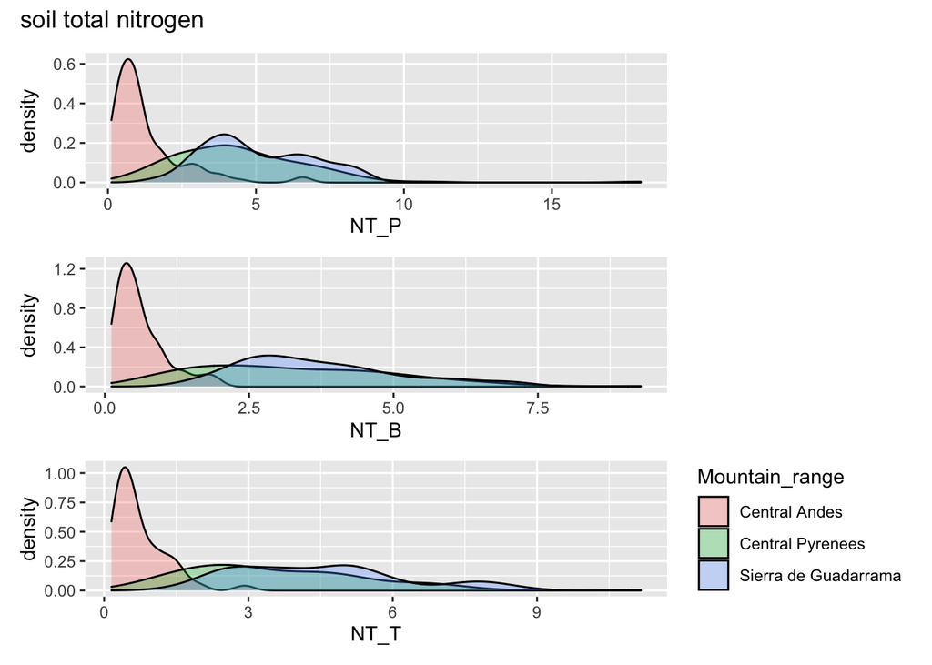

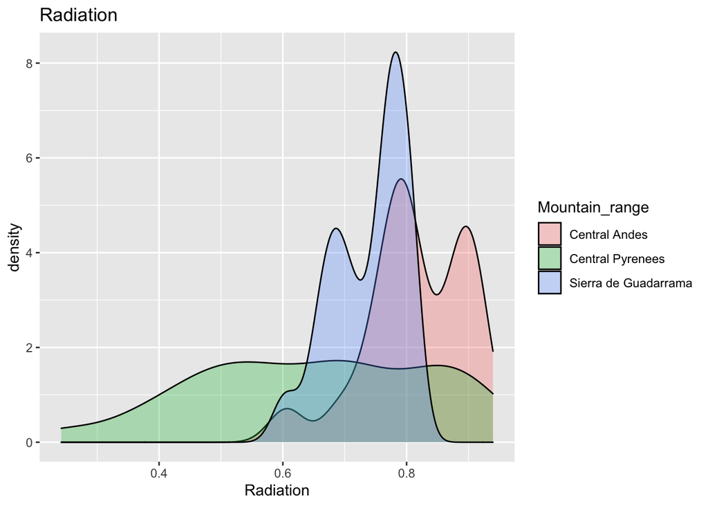

The analysis of the “Naive Bayes” model comes back to the analysis of the density graphs of each variable by mountain range. From these density graphs we agree on what has been seen before, that the *pH* is a very good feature to classify the mountains. Indeed, *pH_T* *ph_B* and *ph_P* is medium in Central Andes, lower in Sierra de Guadarrama and higher in Central Pyrenees.

In addition to that, the observation of other variables such as phosphatase enzyme, (*Phos_P, Phos_B, Phos_T*), β-glucosidase enzyme (*Glu_B*, *Glu_P*, *Glu_T*) , soil organic carbon (*SOC_T*, *SOC_B*, *SOC_P*), soil total nitrogen (*NT_P*,*NT_B*,*NT_T*), electrical conductivity (*Cond_P*,*Cond_B*, *Cond_T*), and the *radiation* could allow us to get an idea of the mountain we are on. Indeed, a radiation lower than 0,6 indicates rather the Central Pyrenees. The electrical conductivity allows us to distinguish the Central Andes from the Central Pyrenees, since it is higher for the latter. If we look at the soil total nitrogen, we see that it is lower for the Central Andes than for the two others. The soil organic carbon allows us to distinguish the Central Andes from the Sierra de Guadarrama, since it is higher for this last one. The β-glucosidase enzyme is present at approximately the same level in Central Andes and Central Pyrenees but has a higher value in Sierra de Guadarrama. It is about the same for the phosphatase enzyme

However, some variables do not allow us to determine the mountain at all. It is the case by observing the phosphorus (*PT_P, PT_B, PT_T*) or the potassium content (*K_P, K_B, K_T*).

### Accuracy of Naive bayes

```
## Confusion Matrix and Statistics
##
##                       Reference
## Prediction             Central Andes Central Pyrenees Sierra de Guadarrama
##   Central Andes                   17                0                    0
##   Central Pyrenees                 3               29                    0
##   Sierra de Guadarrama             1                0                   58
##
## Overall Statistics
##
##                Accuracy : 0.963
##                  95% CI : (0.9079, 0.9898)
##     No Information Rate : 0.537
##     P-Value [Acc > NIR] : < 2.2e-16
##
##                   Kappa : 0.9379
##
##  Mcnemar's Test P-Value : NA
##
## Statistics by Class:
##
##                      Class: Central Andes Class: Central Pyrenees
## Sensitivity                        0.8095                  1.0000
## Specificity                        1.0000                  0.9620
## Pos Pred Value                     1.0000                  0.9063
## Neg Pred Value                     0.9560                  1.0000
## Prevalence                         0.1944                  0.2685
## Detection Rate                     0.1574                  0.2685
## Detection Prevalence               0.1574                  0.2963
## Balanced Accuracy                  0.9048                  0.9810
##                      Class: Sierra de Guadarrama
## Sensitivity                               1.0000
## Specificity                               0.9800
## Pos Pred Value                            0.9831
## Neg Pred Value                            1.0000
## Prevalence                                0.5370
## Detection Rate                            0.5370
## Detection Prevalence                      0.5463
## Balanced Accuracy                         0.9900
```

### K-NN Model

We use a 2-NN to predict the test set using the training set

```
## Confusion Matrix and Statistics
##
##                       Reference
## Prediction             Central Andes Central Pyrenees Sierra de Guadarrama
##   Central Andes                   21                0                    0
##   Central Pyrenees                 0               29                    0
##   Sierra de Guadarrama             0                0                   58
##
## Overall Statistics
##
##                Accuracy : 1
##                  95% CI : (0.9664, 1)
##     No Information Rate : 0.537
##     P-Value [Acc > NIR] : < 2.2e-16
##
##                   Kappa : 1
##
##  Mcnemar's Test P-Value : NA
##
## Statistics by Class:
##
##                      Class: Central Andes Class: Central Pyrenees
## Sensitivity                        1.0000                  1.0000
## Specificity                        1.0000                  1.0000
## Pos Pred Value                     1.0000                  1.0000
## Neg Pred Value                     1.0000                  1.0000
## Prevalence                         0.1944                  0.2685
## Detection Rate                     0.1944                  0.2685
## Detection Prevalence               0.1944                  0.2685
## Balanced Accuracy                  1.0000                  1.0000
##                      Class: Sierra de Guadarrama
## Sensitivity                                1.000
## Specificity                                1.000
## Pos Pred Value                             1.000
## Neg Pred Value                             1.000
## Prevalence                                 0.537
## Detection Rate                             0.537
## Detection Prevalence                       0.537
## Balanced Accuracy                          1.000
```

With this KNN supervised method, the prediction made on the test set gives us an accuracy of 1. It looks indeed perfect and attractive, but it is completely biased by the fact that subplot can be identical to plot. Therefore, there is an overlay in the observations and the distance computed is 0. What we need to do is to make a unite dataset with no observations overlaid.

### Analysis with unique dataset

We now want to replicate the above models with a another training set and test set that has been through a boostraping method. To do so, we first want to delete all the repeated observations from the original cleaned dataset.

#### Unique

We remove every replicated data with the “unique” function. We decided to do so to see if we will have better results. As we see above, the accuracy of our models are very high and this is normally unlikely. So we are testing if the high accuracy is due to the fact that we have duplicated observations in our dataset. (The scientists did sample different observations, but it comes out that the samples are exactly the same, they are maybe different at a very very small digits.)

#### Count

We have seen that the new Unique data set is largely unbalanced. The mountain that has the most information is now the one with the less observations, so information.

Sierra de Gaudarrama, after removing every replicated data with the “unique” function, only have 39 observations. It is unbalanced indeed, and insufficient to make accurate classification methods.

#### Split in a new training set and test set

Now that we have a new dataset, we have to split it again into a training set (**Mountain_df.tr_notsubs**) and a test set (**Mountain_df.te** ).

### Random Forest

Once the duplicates are removed, we are left with a data set that is low in data, especially in the observations for the **Sierra de Guadarrama** class. With the poverty of our data we want to test an implementation of a random forest model. Indeed, the bagging should allow us to overcome the lack of data and give the best possible model. Another advantage of the random forest model is that it allows us to easily identify the importance of variables.

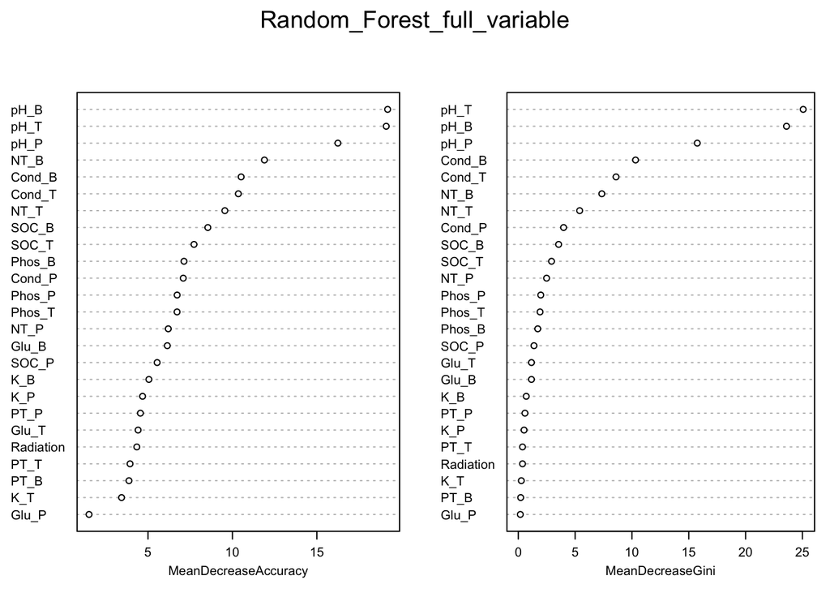

Here we can see the difference between the descending average of the precision that each variable adds to the model and the descending average of Gini which is a coefficient that shows the contribution of each variable to the homogeneity of nodes and leaves. We notice that some variables have a higher precision importance than their importance based on their Gini score, for our selection of future candidate variables for a simpler model we will make a compromise between these two measures.

From the variable importance we see that the variable **pH_P**, **pH_T** and **pH_B** are very important. We can then say that the *pH* in general is important.

```
##                       predtr
##                        Central Andes Central Pyrenees Sierra de Guadarrama
##   Central Andes                   69                0                    0
##   Central Pyrenees                 0              107                    0
##   Sierra de Guadarrama             0                0                   29
```

```
## Accuracy of the train set = 1
```

The first table is the confusion matrix of the Random Forest model on the training set. Therefore it is normal to have an accuracy of 1 since the model already knows the observations.

```
##                       predte
##                        Central Andes Central Pyrenees Sierra de Guadarrama
##   Central Andes                   31                0                    0
##   Central Pyrenees                 0               28                    0
##   Sierra de Guadarrama             0                0                   10
```

```
## Accuracy of the test set = 1
```

Then the second table is the confusion matrix of the random forest model on the test set. We still have a precision of 1, which makes it a good model. We have to keep in mind that the data set is very small and not necessarily representative of a larger sample.

Currently the model has many variables and we notice that many of them are not important for mountain classification. We are therefore thinking of testing a model with the 5 main variables to avoid overloading the model. Having less variables would allow us to predict a larger set of data with less computational power and resources. Moreover, the time saving could also be done during sampling, since less chemical elements would be needed to predict the class.

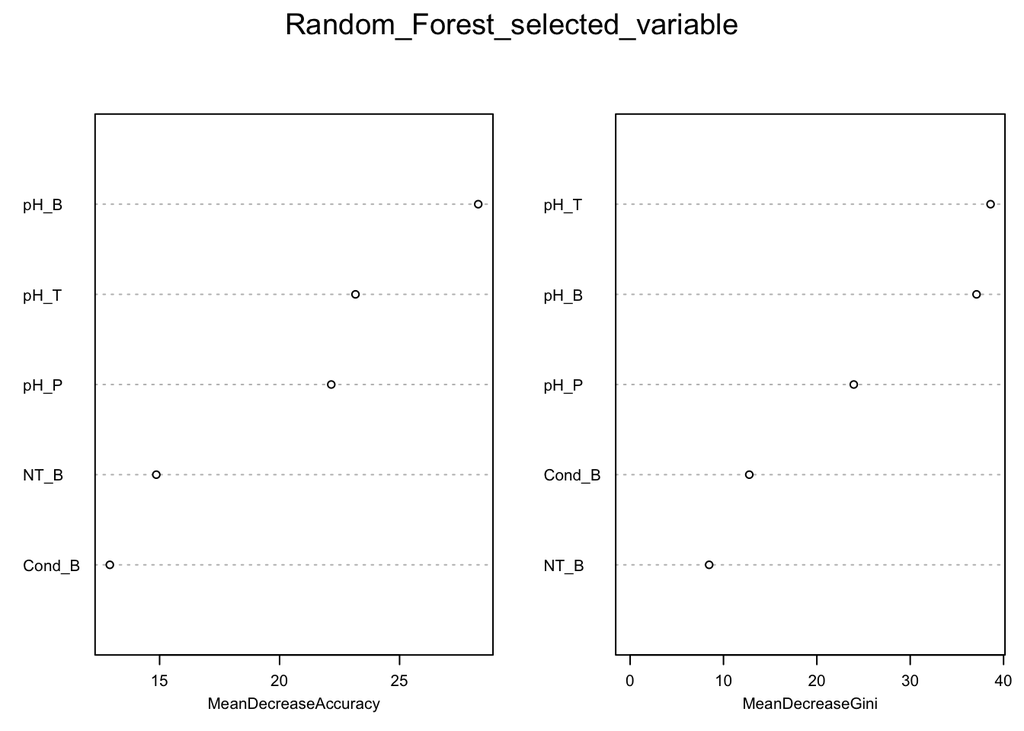

```
##                       predtr
##                        Central Andes Central Pyrenees Sierra de Guadarrama
##   Central Andes                   69                0                    0
##   Central Pyrenees                 0              107                    0
##   Sierra de Guadarrama             0                0                   29
```

```
## Accuracy of the train set = 1
```

```
##                       predte
##                        Central Andes Central Pyrenees Sierra de Guadarrama
##   Central Andes                   31                0                    0
##   Central Pyrenees                 1               27                    0
##   Sierra de Guadarrama             0                0                   10
```

```
## Accuracy of the test set = 0.9855072
```

Even with this model composed of fewer variables we still see a good accuracy of the test set compared to the train set. Here the error comes from the fact that we will have more tendency to predict **Central Andes** since we cannot balance the data between the classes otherwise we will reduce too much the size of the data set.

Overall the random forest model seems to be a good model that can be used with fewer variables while keeping a high accuracy.

But we now bootstrap to re-test some of our models and check if the accuracy changes once the duplicate data is removed.

#### Bootstrap

We can now proceed to the bootstraping with 100 replicates

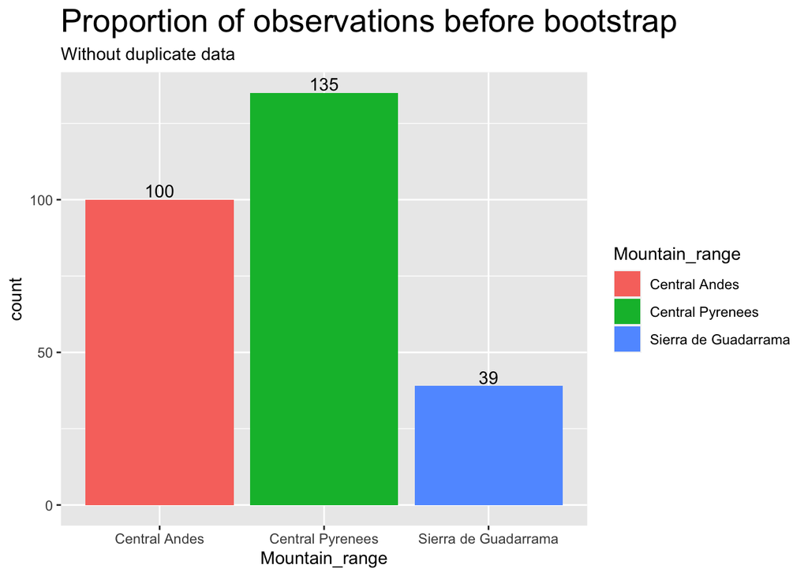

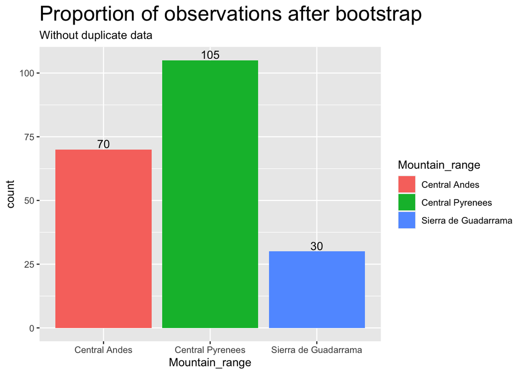

We can now replicate the models.

### Neural Network Model (with Unique bootstraped data)

Simple hyperparameter tuning, this code takes time to run.

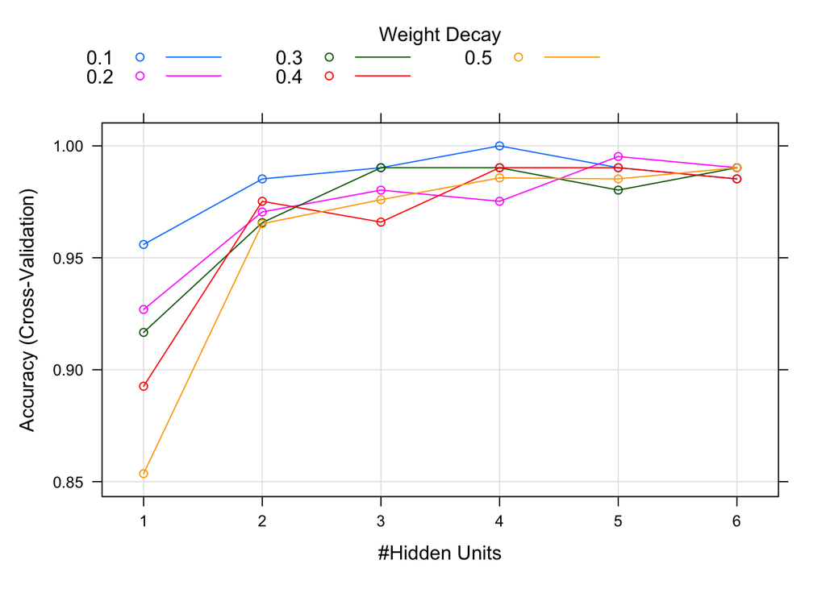

Now that we fitted the model and made the prediction, we can use the confusion matrix to see is the model performed well or not.

```
## Confusion Matrix and Statistics
##
##                       Reference
## Prediction             Central Andes Central Pyrenees Sierra de Guadarrama
##   Central Andes                   24                0                    0
##   Central Pyrenees                 0               39                    0
##   Sierra de Guadarrama             0                0                   10
##
## Overall Statistics
##
##                Accuracy : 1
##                  95% CI : (0.9507, 1)
##     No Information Rate : 0.5342
##     P-Value [Acc > NIR] : < 2.2e-16
##
##                   Kappa : 1
##
##  Mcnemar's Test P-Value : NA
##
## Statistics by Class:
##
##                      Class: Central Andes Class: Central Pyrenees
## Sensitivity                        1.0000                  1.0000
## Specificity                        1.0000                  1.0000
## Pos Pred Value                     1.0000                  1.0000
## Neg Pred Value                     1.0000                  1.0000
## Prevalence                         0.3288                  0.5342
## Detection Rate                     0.3288                  0.5342
## Detection Prevalence               0.3288                  0.5342
## Balanced Accuracy                  1.0000                  1.0000
##                      Class: Sierra de Guadarrama
## Sensitivity                                1.000
## Specificity                                1.000
## Pos Pred Value                             1.000
## Neg Pred Value                             1.000
## Prevalence                                 0.137
## Detection Rate                             0.137
## Detection Prevalence                       0.137
## Balanced Accuracy                          1.000
```

### KNN model (with Unique bootstraped data)

```
## Confusion Matrix and Statistics
##
##                       Reference
## Prediction             Central Andes Central Pyrenees Sierra de Guadarrama
##   Central Andes                   24                0                    0
##   Central Pyrenees                 0               39                    3
##   Sierra de Guadarrama             0                0                    7
##
## Overall Statistics
##
##                Accuracy : 0.9589
##                  95% CI : (0.8846, 0.9914)
##     No Information Rate : 0.5342
##     P-Value [Acc > NIR] : 5.772e-16
##
##                   Kappa : 0.9281
##
##  Mcnemar's Test P-Value : NA
##
## Statistics by Class:
##
##                      Class: Central Andes Class: Central Pyrenees
## Sensitivity                        1.0000                  1.0000
## Specificity                        1.0000                  0.9118
## Pos Pred Value                     1.0000                  0.9286
## Neg Pred Value                     1.0000                  1.0000
## Prevalence                         0.3288                  0.5342
## Detection Rate                     0.3288                  0.5342
## Detection Prevalence               0.3288                  0.5753
## Balanced Accuracy                  1.0000                  0.9559
##                      Class: Sierra de Guadarrama
## Sensitivity                              0.70000
## Specificity                              1.00000
## Pos Pred Value                           1.00000
## Neg Pred Value                           0.95455
## Prevalence                               0.13699
## Detection Rate                           0.09589
## Detection Prevalence                     0.09589
## Balanced Accuracy                        0.85000
```

### Unsupervised learning method

#### Agglomerative Hierarchical Clustering (AGNES) with Manhattan distance

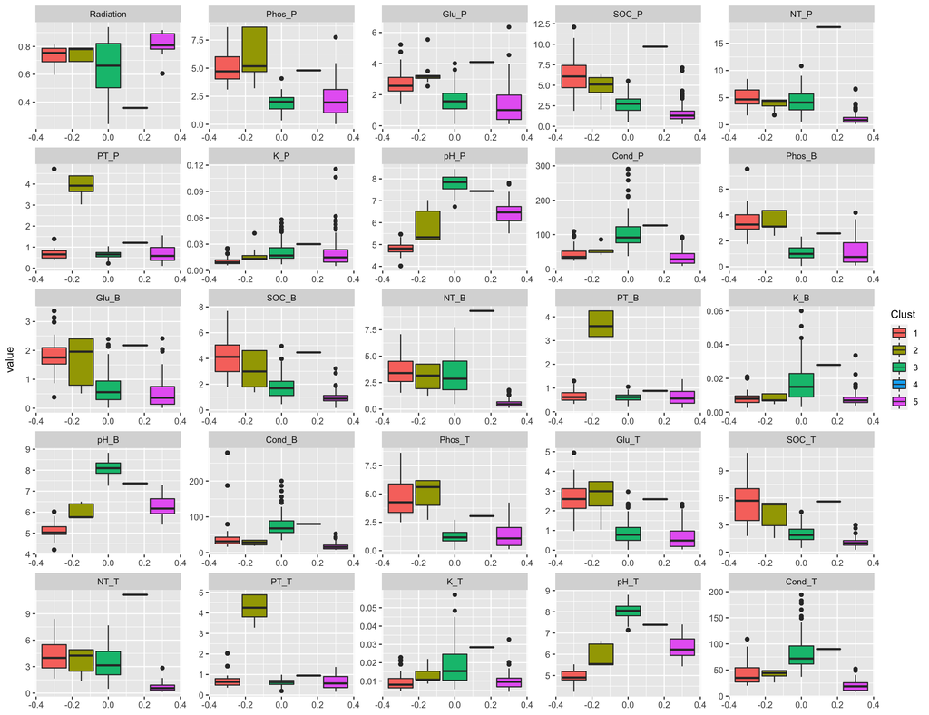

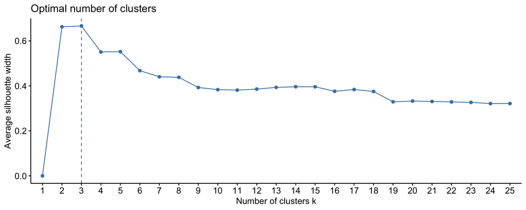

From this analysis, it would have been interesting to know the exact composition of these clusters in order to get the information related to the different mountains.

To conclude, we will do a final score analysis of each models, so we can select the best one.